# Practice Activity 8.1

Author

Devakinandan

# Palmer Penguins Modeling

Import the Palmer Penguins dataset and print out the first few rows.

Suppose we want to predict `bill_depth_mm` using the other variables in the dataset.

**Dummify** all variables that require this.

```python
# Code Here
!pip install palmerpenguins
```

```python
import pandas as pd
from palmerpenguins import load_penguins

penguins = load_penguins()
penguins = penguins.dropna()
penguins_dummified = pd.get_dummies(penguins, columns=['species', 'island', 'sex'], drop_first=True)

penguins_dummified.head()
```

|  | bill_length_mm | bill_depth_mm | flipper_length_mm | body_mass_g | year | species_Chinstrap | species_Gentoo | island_Dream | island_Torgersen | sex_male |
| --- | --- | --- | --- | --- | --- | --- | --- | --- | --- | --- |
| 0 | 39.1 | 18.7 | 181.0 | 3750.0 | 2007 | False | False | False | True | True |
| 1 | 39.5 | 17.4 | 186.0 | 3800.0 | 2007 | False | False | False | True | False |
| 2 | 40.3 | 18.0 | 195.0 | 3250.0 | 2007 | False | False | False | True | False |
| 4 | 36.7 | 19.3 | 193.0 | 3450.0 | 2007 | False | False | False | True | False |
| 5 | 39.3 | 20.6 | 190.0 | 3650.0 | 2007 | False | False | False | True | True |

```python
import pandas as pd
import numpy as np
from palmerpenguins import load_penguins
from sklearn.model_selection import train_test_split
from sklearn.linear_model import LinearRegression
from sklearn.neighbors import KNeighborsRegressor
from sklearn.tree import DecisionTreeRegressor
from sklearn.metrics import mean_squared_error
from plotnine import ggplot, aes, geom_bar, labs, theme_minimal, position_dodge
```

```python
X = penguins_dummified.drop(columns=['bill_depth_mm'])
y = penguins_dummified['bill_depth_mm']

X_train, X_test, y_train, y_test = train_test_split(X, y, test_size=0.2, random_state=42)

models = {
    'Linear Regression': LinearRegression(),
    'kNN (K=3)': KNeighborsRegressor(n_neighbors=3),
    'kNN (K=5)': KNeighborsRegressor(n_neighbors=5),
    'Decision Tree': DecisionTreeRegressor(random_state=42)
}
```

```python
results = []

for name, model in models.items():
    model.fit(X_train, y_train)
    y_train_pred = model.predict(X_train)
    y_test_pred = model.predict(X_test)
    results.append({'Model': name, 'Error Type': 'Training Error', 'MSE': mean_squared_error(y_train, y_train_pred)})
    results.append({'Model': name, 'Error Type': 'Testing Error', 'MSE': mean_squared_error(y_test, y_test_pred)})

results_df = pd.DataFrame(results)
results_df
```

|  | Model | Error Type | MSE |
| --- | --- | --- | --- |
| 0 | Linear Regression | Training Error | 0.529104 |
| 1 | Linear Regression | Testing Error | 0.895856 |
| 2 | kNN (K=3) | Training Error | 1.180835 |
| 3 | kNN (K=3) | Testing Error | 3.151575 |
| 4 | kNN (K=5) | Training Error | 1.574620 |
| 5 | kNN (K=5) | Testing Error | 2.909254 |
| 6 | Decision Tree | Training Error | 0.000000 |
| 7 | Decision Tree | Testing Error | 1.397313 |

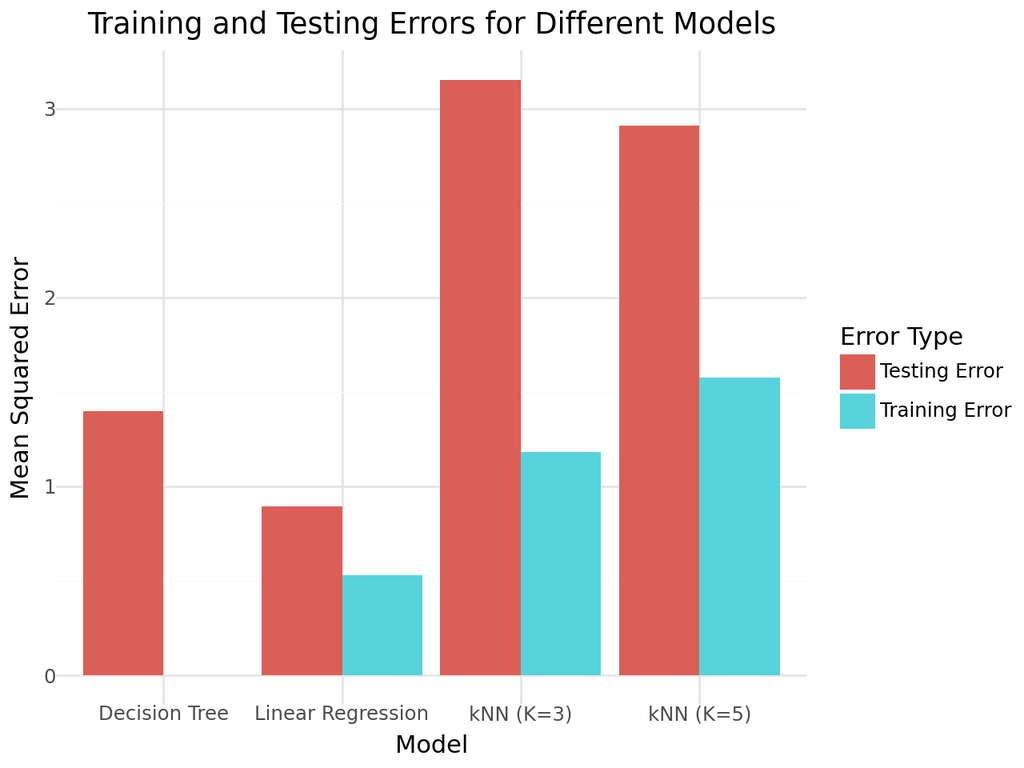

```python
plot = (
    ggplot(results_df, aes(x='Model', y='MSE', fill='Error Type'))
    + geom_bar(stat='identity', position=position_dodge())
    + labs(title='Training and Testing Errors for Different Models', x='Model', y='Mean Squared Error')
    + theme_minimal()
)

plot
```

Let’s use the other variables to predict `bill_depth_mm`. Prepare your data and fit the following models on the entire dataset:

- Your best multiple linear regression model from before
- Two kNN models (for different values of K)
- A decision tree model

Create a plot like the right plot of Fig 1. in our `Model Validation` chapter with the training and test error plotted for each of your four models.

Which of your models was best?

- Linear Regression has the best performance in terms of generalization, with similar training and testing errors.
- Decision Tree and kNN (K=3) both suffer from overfitting, as their testing errors are significantly higher than their training errors.
- kNN (K=5) improves slightly over K=3, but it still struggles compared to Linear Regression.